# Skúška

Patrícia Ivanová

Ako svoje data som zvolila dataset z databázy R-ka toothgrowth. Tento dataset obsahuje merania dĺžky zubov prasiatok v závislosti od veľkosti dávky vitamínu C a od spôsobu, akým bola dávka podaná. Veľkosti dávky boli 0,5 mg/deň, 1 mg/deň a 2 mg/deň. Spôsoby podania vitamínu C boli 2, a to pomarančový džús alebo syntetická kyselina askorbová.

Začneme načítaním dát.

```r
dat <- ToothGrowth
print(dat)
```

```
##     len supp dose
## 1   4.2   VC  0.5
## 2  11.5   VC  0.5
## 3   7.3   VC  0.5
## 4   5.8   VC  0.5
## 5   6.4   VC  0.5
## 6  10.0   VC  0.5
## 7  11.2   VC  0.5
## 8  11.2   VC  0.5
## 9   5.2   VC  0.5
## 10  7.0   VC  0.5
## 11 16.5   VC  1.0
## 12 16.5   VC  1.0
## 13 15.2   VC  1.0
## 14 17.3   VC  1.0
```

[output cut: 46 more lines]

Vykreslíme si graf, v ktorom vidíme závislosť dĺžky zubov prasiatok od množstva dávky vitamínu C a zároveň farebne odlíšime spôsob podania.

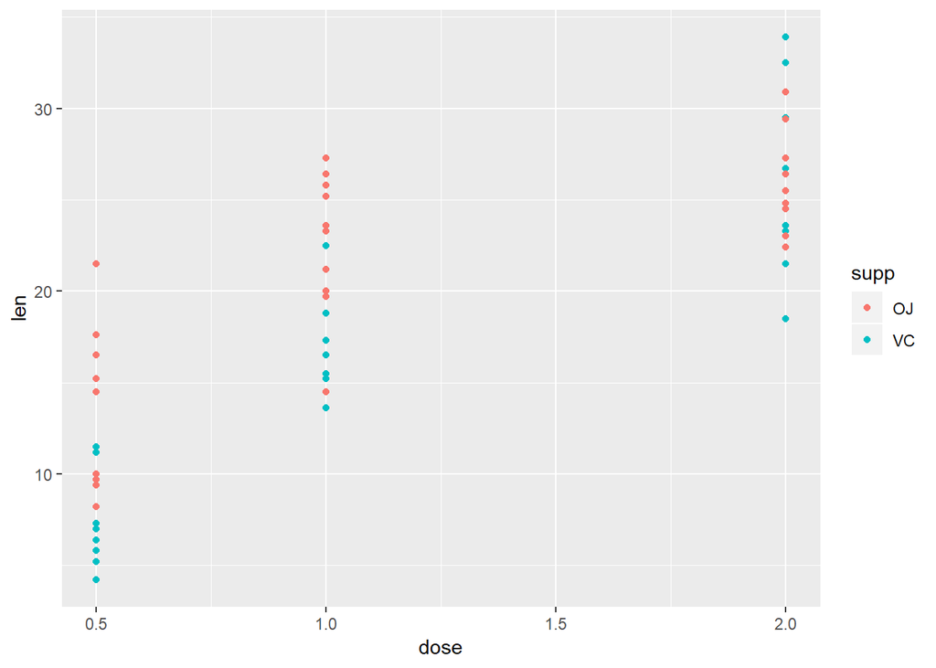

```r
library(ggplot2)
bodgraf <- ggplot(aes(x=dose, y=len),data=dat)+
  geom_point(aes(color=supp))
print(bodgraf)
```

Teraz si vykreslíme boxplot, ktorý nám pomôže lepšie vidieť prípadne závislosti.

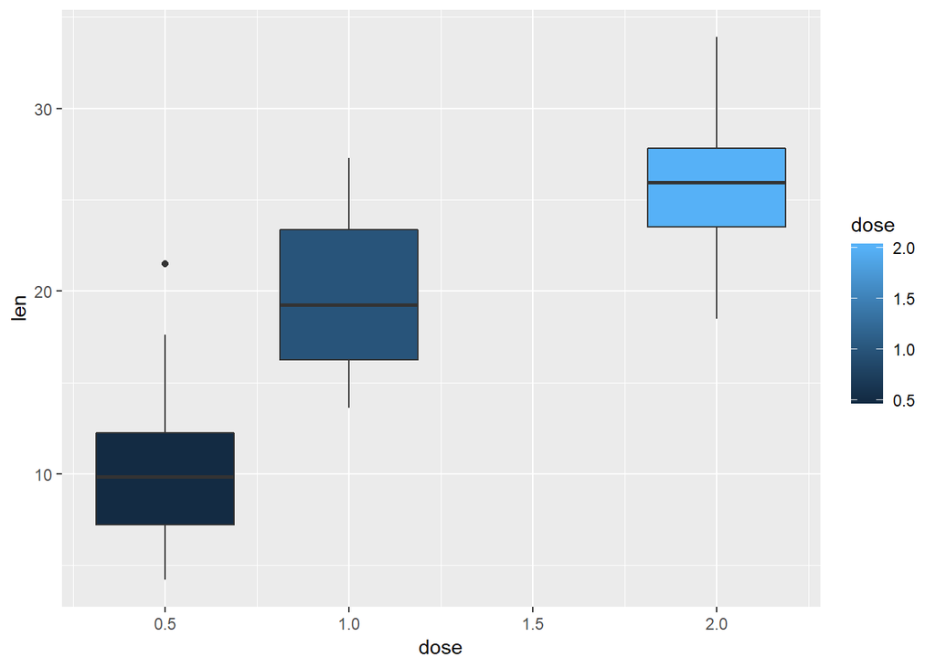

```r
boxgraf <- ggplot(aes(x=dose, y=len, group=dose),data=dat)+
  geom_boxplot(aes(fill=dose))
print(boxgraf)
```

V grafe vidíme, že boxploty sú nerovnomerne rozmiestnené. Dávku teda použijeme ako kategorickú premennú nie ako spojitú premennú.

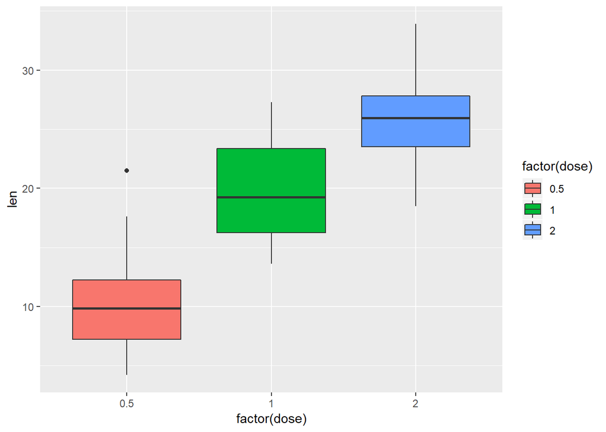

```r
boxgraf <- ggplot(aes(x=factor(dose), y=len),data=dat)+
  geom_boxplot(aes(fill=factor(dose)))
print(boxgraf)
```

Teraz vykreslíme boxplot, v ktorom budeme vidieť prípadné závislosti dĺžky zubov od spôsobu podania dávky.

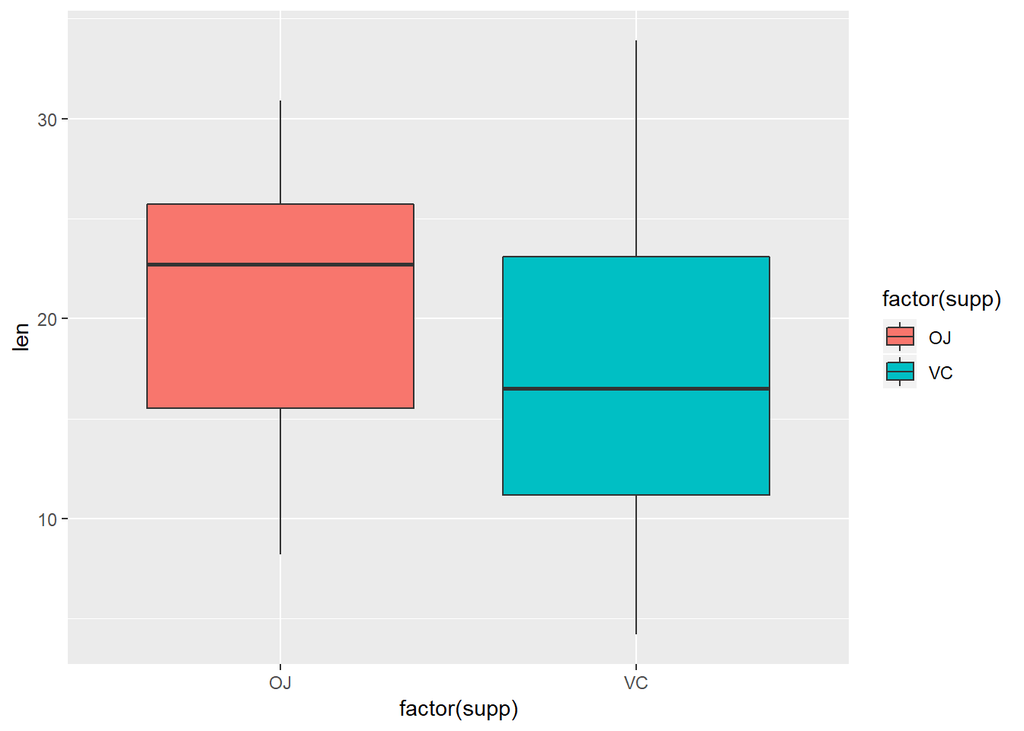

```r
boxgraf <- ggplot(aes(x=factor(supp), y=len),data=dat)+
  geom_boxplot(aes(fill=factor(supp)))
print(boxgraf)
```

V ďalšom grafe zobrazíme efekt spôsobu podania dávky pre jednotlivé množstvá dávky.

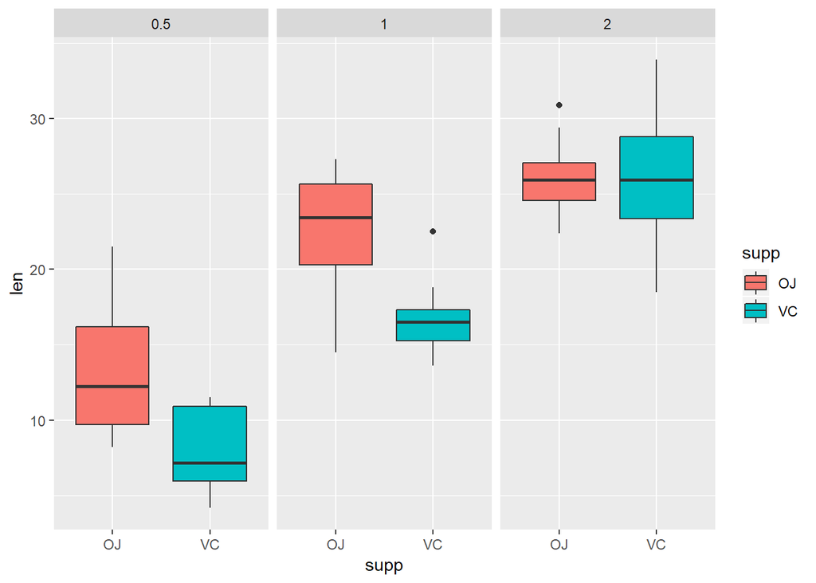

```r
boxgraf <- ggplot(aes(x=supp, y=len),data=dat)+
  geom_boxplot(aes(fill=supp)) +
  facet_wrap(~dose)
print(boxgraf)
```

Teraz chceme porovnať, či je suvis medzi dĺžkou zubov a veľkosťou dávky vitamínu C. Nebereieme ohľad nato akou formou bola dávka podaná. Na túto analýzu použijeme nepárový T-test. Nato si potrebujeme rozdeliť do dvojíc podľa veľkosti dávky.

```r
minastr<-subset(dat,dose %in% c(0.5 , 1.0))
minamax<-subset(dat,dose %in% c(0.5 , 2.0))
stramax<-subset(dat,dose %in% c(1.0 , 2.0))
print(minastr)
```

```
##     len supp dose
## 1   4.2   VC  0.5
## 2  11.5   VC  0.5
## 3   7.3   VC  0.5
## 4   5.8   VC  0.5
## 5   6.4   VC  0.5
## 6  10.0   VC  0.5
## 7  11.2   VC  0.5
## 8  11.2   VC  0.5
## 9   5.2   VC  0.5
## 10  7.0   VC  0.5
## 11 16.5   VC  1.0
## 12 16.5   VC  1.0
## 13 15.2   VC  1.0
## 14 17.3   VC  1.0
```

[output cut: 26 more lines]

Prevedieme nepárový T-test na každej skupine.

```r
t.test(len~dose, paired=FALSE, data=minastr)
```

```
##
##  Welch Two Sample t-test
##
## data:  len by dose
## t = -6.4766, df = 37.986, p-value = 1.268e-07
## alternative hypothesis: true difference in means is not equal to 0
## 95 percent confidence interval:
##  -11.983781  -6.276219
## sample estimates:
## mean in group 0.5   mean in group 1
##            10.605            19.735
```

```r
t.test(len~dose, paired=FALSE, data=minamax)
```

```
##
##  Welch Two Sample t-test
##
## data:  len by dose
## t = -11.799, df = 36.883, p-value = 4.398e-14
## alternative hypothesis: true difference in means is not equal to 0
## 95 percent confidence interval:
##  -18.15617 -12.83383
## sample estimates:
## mean in group 0.5   mean in group 2
##            10.605            26.100
```

```r
t.test(len~dose, paired=FALSE, data=stramax)
```

```
##
##  Welch Two Sample t-test
##
## data:  len by dose
## t = -4.9005, df = 37.101, p-value = 1.906e-05
## alternative hypothesis: true difference in means is not equal to 0
## 95 percent confidence interval:
##  -8.996481 -3.733519
## sample estimates:
## mean in group 1 mean in group 2
##          19.735          26.100
```

Vo výsledkkoch T-testu vidíme, že p hodnota pre všetky dvojice je výrazne nižšia ako 0,05 a teda zvolené dávky majú vplyv na dĺžku zubov prasiatok.

Ďalším nepárovým T-testom vyhodnotíme vplyv spôsobu podania dávky na dĺžku zubov prasiatok.

```r
t.test(len~supp, paired=FALSE, data=dat)
```

```
##
##  Welch Two Sample t-test
##
## data:  len by supp
## t = 1.9153, df = 55.309, p-value = 0.06063
## alternative hypothesis: true difference in means is not equal to 0
## 95 percent confidence interval:
##  -0.1710156  7.5710156
## sample estimates:
## mean in group OJ mean in group VC
##         20.66333         16.96333
```

Výsledkom T-testu je p hodnota 0,06 a teda závislosť nie je štatisticky významná na hladine 0,05.